# Lab 5

Author

Shawheen Ghezavat

View this project on GitHub

# Imports

```python
from sklearn.linear_model import LinearRegression
from sklearn.metrics import mean_squared_error
import numpy as np
import pandas as pd
from plotnine import *
import re
```

# Part One: Data Exploration

## Read in the dataset, and display some summaries of the data

```python
df = pd.read_csv("https://www.dropbox.com/s/bocjjyo1ehr5auz/insurance_costs_1.csv?dl=1")
df.describe()
```

|  | age | bmi | charges |
| --- | --- | --- | --- |
| count | 431.000000 | 431.000000 | 431.000000 |
| mean | 37.960557 | 30.768898 | 12297.098118 |
| std | 16.363909 | 6.111362 | 11876.527128 |
| min | 18.000000 | 15.960000 | 1131.506600 |
| 25% | 22.000000 | 26.357500 | 2710.444575 |
| 50% | 34.000000 | 30.590000 | 9866.304850 |
| 75% | 55.000000 | 35.272500 | 14510.872600 |
| max | 64.000000 | 49.060000 | 55135.402090 |

## Fix any concerns you have about the data.

```python
# create dummy variables

df['smoker_yes'] = pd.get_dummies(df['smoker'], drop_first=True, dtype=int)
df['sex_male'] = pd.get_dummies(df['sex'], drop_first=True, dtype=int)
region_dummies = pd.get_dummies(df['region'], prefix='region', drop_first=True, dtype=int)
df = pd.concat([df, region_dummies], axis=1)

print(df.isnull().sum())
df.info()
```

```
age                 0
sex                 0
bmi                 0
smoker              0
region              0
charges             0
smoker_yes          0
sex_male            0
region_northwest    0
region_southeast    0
region_southwest    0
dtype: int64
<class 'pandas.core.frame.DataFrame'>
RangeIndex: 431 entries, 0 to 430
Data columns (total 11 columns):
 #   Column            Non-Null Count  Dtype
---  ------            --------------  -----
 0   age               431 non-null    int64
 1   sex               431 non-null    object
 2   bmi               431 non-null    float64
 3   smoker            431 non-null    object
 4   region            431 non-null    object
 5   charges           431 non-null    float64
 6   smoker_yes        431 non-null    int64
 7   sex_male          431 non-null    int64
 8   region_northwest  431 non-null    int64
 9   region_southeast  431 non-null    int64
 10  region_southwest  431 non-null    int64
dtypes: float64(2), int64(6), object(3)
memory usage: 37.2+ KB
```

## Three plots comparing the response variable charges to one of the predictor variables.

```python
# scatter plot of age vs. charges
plot_age_charges = (
    ggplot(df, aes(x='age', y='charges'))
    + geom_point()
    + labs(title='Age vs. Charges', x='Age', y='Charges')
)
# box plot of smoker vs. charges
plot_smoker_charges = (
    ggplot(df, aes(x='smoker', y='charges'))
    + geom_boxplot()
    + labs(title='Smoker vs. Charges', x='Smoker', y='Charges')
)
# box plot of region vs. charges
plot_region_charges = (
    ggplot(df, aes(x='region', y='charges'))
    + geom_boxplot()
    + labs(title='Region vs. Charges', x='Region', y='Charges')
)
```

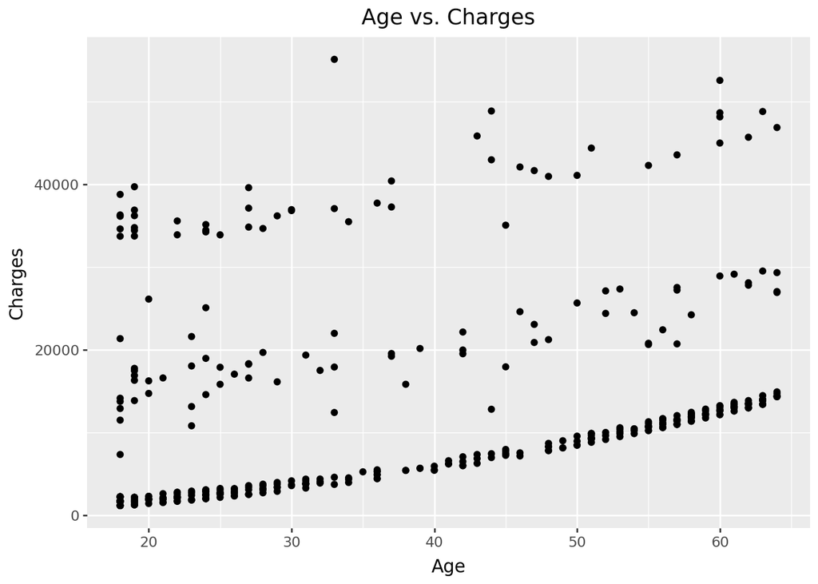

```python
plot_age_charges
```

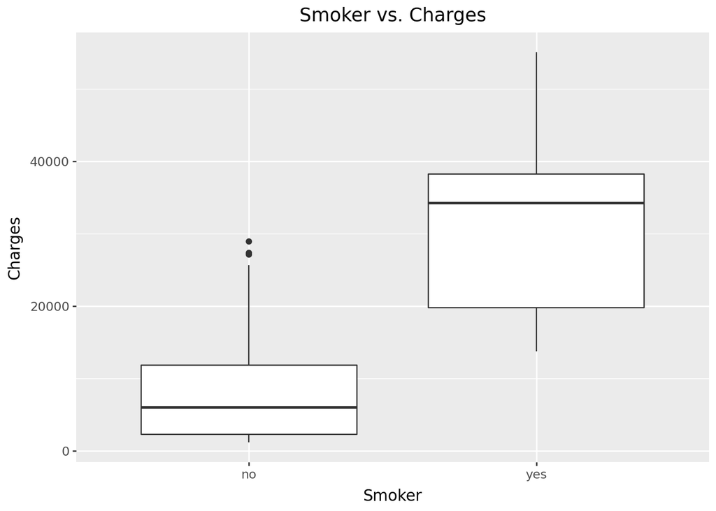

```python
plot_smoker_charges
```

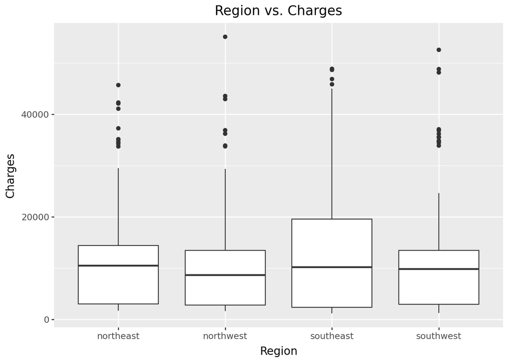

```python
plot_region_charges
```

## Brief Summary

Smoker: Most impactful predictor, as smokers pay roughly 4-5x more on average

Region: Minimal impact, as all regions show similar charge distributions

# Part Two: Simple Linear Models

## Age and Charges

```python
# X and y
X = df[['age']]
y = df['charges']

# build and fit the linear model
model_age = LinearRegression()
model_age.fit(X, y)

# discuss the model fit
print("Model Intercept:", model_age.intercept_)
print("Model Coefficient for Age:", model_age.coef_[0])
print("R-squared:", model_age.score(X, y))
```

```
Model Intercept: 3611.758798507106
Model Coefficient for Age: 228.79904937243668
R-squared: 0.09938105452062707
```

The coefficient for age ~228.80 indicates that for every one-year increase in age, the insurance charges are estimated to increase by approximately 228.80, holding all other factors constant.

## Age, Sex, and Charges

```python
# prepare features and target
X_age_sex = df[['age', 'sex_male']]
y = df['charges']

# build and fit the linear model
model_age_sex = LinearRegression()
model_age_sex.fit(X_age_sex, y)

# discuss the model fit
print("PART 2: Model with Age and Sex")
print("Model Intercept:", model_age_sex.intercept_)
print("Model Coefficient for Age:", model_age_sex.coef_[0])
print("Model Coefficient for Sex (Male):", model_age_sex.coef_[1])
print("R-squared:", model_age_sex.score(X_age_sex, y))
```

```
PART 2: Model with Age and Sex
Model Intercept: 3315.332346534262
Model Coefficient for Age: 228.42586235855936
Model Coefficient for Sex (Male): 649.8325899725355
R-squared: 0.10012952499706396
```

The coefficient for age ~228.43 indicates that for every one-year increase in age, the insurance charges increase by approximately 228.43, holding sex constant.

The coefficient for sex ~649.83 indicates that males have insurance charges that are approximately 649.83 higher than females, holding age constant.

## Age, Smoker, and Charges

```python
# prepare features and target
X_age_smoker = df[['age', 'smoker_yes']]
y = df['charges']

# build and fit the linear model
model_age_smoker = LinearRegression()
model_age_smoker.fit(X_age_smoker, y)

# discuss the model fit
print("PART 3: Model with Age and Smoker")
print("Model Intercept:", model_age_smoker.intercept_)
print("Model Coefficient for Age:", model_age_smoker.coef_[0])
print("Model Coefficient for Smoker (Yes):", model_age_smoker.coef_[1])
print("R-squared:", model_age_smoker.score(X_age_smoker, y))
```

```
PART 3: Model with Age and Smoker
Model Intercept: -2166.852295375429
Model Coefficient for Age: 253.1453554882845
Model Coefficient for Smoker (Yes): 24048.867437953864
R-squared: 0.7603842948069405
```

The coefficient for age ~253.15 indicates that for every one-year increase in age, the insurance charges increase by approximately 253.15, holding smoking status constant.

The coefficient for smoker 24048.87 indicates that smokers have insurance charges that are approximately 24048.87 higher than non-smokers, holding age constant.

## Which model fits the data better?

```python
# predictions from both models
y_pred_age_sex = model_age_sex.predict(X_age_sex)
y_pred_age_smoker = model_age_smoker.predict(X_age_smoker)

# MSE for both models
mse_age_sex = mean_squared_error(y, y_pred_age_sex)
mse_age_smoker = mean_squared_error(y, y_pred_age_smoker)

# r-squared values (already calculated, but showing again for comparison)
r2_age_sex = model_age_sex.score(X_age_sex, y)
r2_age_smoker = model_age_smoker.score(X_age_smoker, y)

# display comparison
print("MODEL COMPARISON: Q2 (Age + Sex) vs Q3 (Age + Smoker)")
print("\nModel Q2 (Age + Sex):")
print(f"  R-squared: {r2_age_sex:.4f}")
print(f"  MSE: ${mse_age_sex:,.2f}")
print(f"  RMSE: ${np.sqrt(mse_age_sex):,.2f}")

print("\nModel Q3 (Age + Smoker):")
print(f"  R-squared: {r2_age_smoker:.4f}")
print(f"  MSE: ${mse_age_smoker:,.2f}")
print(f"  RMSE: ${np.sqrt(mse_age_smoker):,.2f}")
```

```
MODEL COMPARISON: Q2 (Age + Sex) vs Q3 (Age + Smoker)

Model Q2 (Age + Sex):
  R-squared: 0.1001
  MSE: $126,633,939.68
  RMSE: $11,253.17

Model Q3 (Age + Smoker):
  R-squared: 0.7604
  MSE: $33,719,831.47
  RMSE: $5,806.88
```

The model from Q3 (Age + Smoker) has a lower MSE of $33,719,831.47 compared to Q2 (Age + Sex) which has an MSE of $126,633,939.68. The lower MSE indicates that predictions from the Age + Smoker model are substantially closer to the actual insurance charges.

The model from Q3 (Age + Smoker) also has a larger R-squared value of 0.7604 compared to Q2 (Age + Sex) which has an R-squared value of 0.1001, meaning the Age + Smoker model explains 76.04% of the variance in insurance charges, compared to 10.01% for Age + Sex.

Therefore, we can say that the model from Q3 (Age + Smoker) better fits the data!

# Part Three: Multiple Linear Models

## Fit a model that uses age and bmi as predictors

```python
X_age_bmi = df[['age', 'bmi']]
y = df['charges']

model_age_bmi = LinearRegression()
model_age_bmi.fit(X_age_bmi, y)

y_pred_age_bmi = model_age_bmi.predict(X_age_bmi)
mse_age_bmi = mean_squared_error(y, y_pred_age_bmi)
r2_age_bmi = model_age_bmi.score(X_age_bmi, y)

print("Q1: Model with Age and BMI")
print("Model Intercept:", model_age_bmi.intercept_)
print("Model Coefficient for Age:", model_age_bmi.coef_[0])
print("Model Coefficient for BMI:", model_age_bmi.coef_[1])
print("R-squared:", r2_age_bmi)
print("MSE:", mse_age_bmi)
print("RMSE:", np.sqrt(mse_age_bmi))

# compare to Part Two Q1 (age only model)
print("\nComparison to Part Two Q1 (Age only):")
print(f"R-squared - Age only: {model_age.score(X, y):.4f}")
print(f"R-squared - Age + BMI: {r2_age_bmi:.4f}")
print(f"MSE - Age only: {mean_squared_error(y, model_age.predict(X)):,.2f}")
print(f"MSE - Age + BMI: {mse_age_bmi:,.2f}")
```

```
Q1: Model with Age and BMI
Model Intercept: -4627.533445708483
Model Coefficient for Age: 216.2972147234252
Model Coefficient for BMI: 283.203801255403
R-squared: 0.12032144234129338
MSE: 123792439.58129103
RMSE: 11126.205084452247

Comparison to Part Two Q1 (Age only):
R-squared - Age only: 0.0994
R-squared - Age + BMI: 0.1203
MSE - Age only: 126,739,267.91
MSE - Age + BMI: 123,792,439.58
```

Compared to the model from Q1 of Part Two (Age), this model (Age + BMI) has a lower MSE of 123,792,439.58 compared to 126,739,267.91. It also has a higher R squared value of 0.1203 compared to 0.0994 of the moodel from Q1 Part Two (Age). This make our new model (Age + BMI) a better fit for the data.

## Fit a model that uses age and age^2 as predictors

```python
# Q2: Model with Age and Age^2
df['age_squared'] = df['age'] ** 2
X_age_poly2 = df[['age', 'age_squared']]

model_age_poly2 = LinearRegression()
model_age_poly2.fit(X_age_poly2, y)

y_pred_age_poly2 = model_age_poly2.predict(X_age_poly2)
mse_age_poly2 = mean_squared_error(y, y_pred_age_poly2)
r2_age_poly2 = model_age_poly2.score(X_age_poly2, y)

print("Q2: Model with Age and Age^2")
print("Model Intercept:", model_age_poly2.intercept_)
print("Model Coefficient for Age:", model_age_poly2.coef_[0])
print("Model Coefficient for Age^2:", model_age_poly2.coef_[1])
print("R-squared:", r2_age_poly2)
print("MSE:", mse_age_poly2)
print("RMSE:", np.sqrt(mse_age_poly2))

print("\nComparison to Part Two Q1 (Age only):")
print(f"R-squared - Age only: {model_age.score(X, y):.4f}")
print(f"R-squared - Age + Age^2: {r2_age_poly2:.4f}")
print(f"MSE - Age only: {mean_squared_error(y, model_age.predict(X)):,.2f}")
print(f"MSE - Age + Age^2: {mse_age_poly2:,.2f}")
```

```
Q2: Model with Age and Age^2
Model Intercept: 2299.7305687266908
Model Coefficient for Age: 308.4281698424921
Model Coefficient for Age^2: -1.001508893404006
R-squared: 0.09958694669946933
MSE: 126710293.80956802
RMSE: 11256.5666972469

Comparison to Part Two Q1 (Age only):
R-squared - Age only: 0.0994
R-squared - Age + Age^2: 0.0996
MSE - Age only: 126,739,267.91
MSE - Age + Age^2: 126,710,293.81
```

This new model using Age and Age^2, has a slightly lower MSE (126,710,293.81) and a slight higher R-squared (0.0996) compared to the model from Q1 Part Two (Age). This means the new model is a better fit for the data compared to the old model from Part Two Q1 (Age), as it has a slightly lower error and explains slighlty more of the data’s variance.

## Fit a polynomial model of degree 4

```python
X_poly4 = pd.DataFrame(df['age'])
for i in range(2, 5):
    X_poly4[f'age_deg{i}'] = df['age'] ** i

model_poly4 = LinearRegression()
model_poly4.fit(X_poly4, y)

y_pred_poly4 = model_poly4.predict(X_poly4)
mse_poly4 = mean_squared_error(y, y_pred_poly4)
r2_poly4 = model_poly4.score(X_poly4, y)

print("Q3: Polynomial Model of Degree 4")
print("Model Intercept:", model_poly4.intercept_)
print("Model Coefficients:", model_poly4.coef_)
print("R-squared:", r2_poly4)
print("MSE:", mse_poly4)
print("RMSE:", np.sqrt(mse_poly4))

print("\nComparison to Part Two Q1 (Age only):")
print(f"R-squared - Age only: {model_age.score(X, y):.4f}")
print(f"R-squared - Degree 4: {r2_poly4:.4f}")
print(f"MSE - Age only: {mean_squared_error(y, model_age.predict(X)):,.2f}")
print(f"MSE - Degree 4: {mse_poly4:,.2f}")
```

```
Q3: Polynomial Model of Degree 4
Model Intercept: 68637.89783096006
Model Coefficients: [-7.94841022e+03  3.58110163e+02 -6.47905090e+00  4.12933982e-02]
R-squared: 0.10782931453183864
MSE: 125550389.64569817
RMSE: 11204.927025451712

Comparison to Part Two Q1 (Age only):
R-squared - Age only: 0.0994
R-squared - Degree 4: 0.1078
MSE - Age only: 126,739,267.91
MSE - Degree 4: 125,550,389.65
```

This new model using a degree four polynomial, has a slightly lower MSE (125,550,389.65) and a slight higher R-squared (0.1078) compared to the model from Q1 Part Two (Age). This means the new model is a better fit for the data compared to the old model from Part Two Q1 (Age), as it has a slightly lower error and explains slighlty more of the data’s variance.

## Fit a polynomial model of degree 12

```python
X_poly12 = pd.DataFrame(df['age'])
for i in range(2, 13):
    X_poly12[f'age_deg{i}'] = df['age'] ** i

model_poly12 = LinearRegression()
model_poly12.fit(X_poly12, y)

y_pred_poly12 = model_poly12.predict(X_poly12)
mse_poly12 = mean_squared_error(y, y_pred_poly12)
r2_poly12 = model_poly12.score(X_poly12, y)

print("Q4: Polynomial Model of Degree 12")
print("Model Intercept:", model_poly12.intercept_)
print("Model Coefficients:", model_poly12.coef_)
print("R-squared:", r2_poly12)
print("MSE:", mse_poly12)
print("RMSE:", np.sqrt(mse_poly12))

print("\nComparison to Part Two Q1 (Age only):")
print(f"R-squared - Age only: {model_age.score(X, y):.4f}")
print(f"R-squared - Degree 12: {r2_poly12:.4f}")
print(f"MSE - Age only: {mean_squared_error(y, model_age.predict(X)):,.2f}")
print(f"MSE - Degree 12: {mse_poly12:,.2f}")
```

```
Q4: Polynomial Model of Degree 12
Model Intercept: 7452.2823451165605
Model Coefficients: [ 3.04916819e-12  8.39792599e-11  3.46360971e-09  7.55961594e-08
  1.26243832e-06  1.25112272e-05 -2.08396674e-08 -1.85914353e-08
  4.09818451e-10 -2.52044337e-12 -1.01992348e-17  1.42766008e-16]
R-squared: 0.10908947739013564
MSE: 125373053.69367324
RMSE: 11197.010926746176

Comparison to Part Two Q1 (Age only):
R-squared - Age only: 0.0994
R-squared - Degree 12: 0.1091
MSE - Age only: 126,739,267.91
MSE - Degree 12: 125,373,053.69
```

This new model using a degree 12 polynomial, has a slightly lower MSE (125,373,053.69) and a slight higher R-squared (0.1091) compared to the model from Q1 Part Two (Age). This means the new model is a better fit for the data compared to the old model from Part Two Q1 (Age), as it has a slightly lower error and explains slighlty more of the data’s variance.

## Summary of all models

```python
print("Q5: SUMMARY - ALL MODELS")

models_summary = pd.DataFrame({
    'Model': ['Age only', 'Age + BMI', 'Age + Age^2', 'Degree 4', 'Degree 12'],
    'R-squared': [
        model_age.score(X, y),
        r2_age_bmi,
        r2_age_poly2,
        r2_poly4,
        r2_poly12
    ],
    'MSE': [
        mean_squared_error(y, model_age.predict(X)),
        mse_age_bmi,
        mse_age_poly2,
        mse_poly4,
        mse_poly12
    ]
})

print(models_summary.to_string(index=False))
print("\nBest model by R-squared:", models_summary.loc[models_summary['R-squared'].idxmax(), 'Model'])
print("Best model by MSE (lowest):", models_summary.loc[models_summary['MSE'].idxmin(), 'Model'])
```

```
Q5: SUMMARY - ALL MODELS
      Model  R-squared          MSE
   Age only   0.099381 1.267393e+08
  Age + BMI   0.120321 1.237924e+08
Age + Age^2   0.099587 1.267103e+08
   Degree 4   0.107829 1.255504e+08
  Degree 12   0.109089 1.253731e+08

Best model by R-squared: Age + BMI
Best model by MSE (lowest): Age + BMI
```

## Plot the predictions from your model in Q4 (Degree 12 Polynomial)

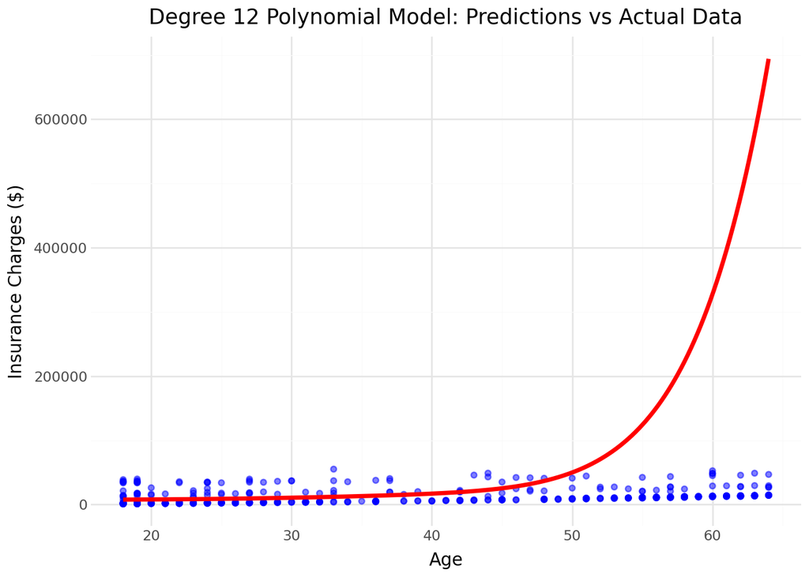

```python
# create prediction data
new_X_poly12 = pd.DataFrame(np.linspace(df['age'].min(), df['age'].max(), num=1000), columns=['age'])
for i in range(2, 13):
    new_X_poly12[f'age_deg{i}'] = new_X_poly12['age'] ** i

new_Y_poly12_pred = model_poly12.predict(new_X_poly12)

# create dataframe for plotting
plot_df = pd.DataFrame({
    'age': new_X_poly12['age'],
    'charges': new_Y_poly12_pred
})

# create plot
plot = (
    ggplot() +
    geom_point(data=df, mapping=aes(x='age', y='charges'), alpha=0.5, color='blue') +
    geom_line(data=plot_df, mapping=aes(x='age', y='charges'), color='red', size=1.5) +
    labs(
        title='Degree 12 Polynomial Model: Predictions vs Actual Data',
        x='Age',
        y='Insurance Charges ($)'
    ) +
    theme_minimal()
)

plot
```

# Part Four: New data

```python
# load data
df_new = pd.read_csv('https://www.dropbox.com/s/sky86agc4s8c6qe/insurance_costs_2.csv?dl=1')

# dummies and append to df_new
df_new['smoker_yes'] = pd.get_dummies(df_new['smoker'], drop_first=True, dtype=int)
df_new['sex_male'] = pd.get_dummies(df_new['sex'], drop_first=True, dtype=int)
region_dummies_new = pd.get_dummies(df_new['region'], prefix='region', drop_first=True, dtype=int)
df_new = pd.concat([df_new, region_dummies_new], axis=1)
```

## Only age as a predictor

```python
X_train_1 = df[['age']]
y_train = df['charges']

model_1 = LinearRegression()
model_1.fit(X_train_1, y_train)

X_test_1 = df_new[['age']]
y_test = df_new['charges']
y_pred_1 = model_1.predict(X_test_1)
mse_1 = mean_squared_error(y_test, y_pred_1)

print("\nModel 1: Only age")
print(f"MSE on new data: {mse_1:,.2f}")
```

```
Model 1: Only age
MSE on new data: 136,077,136.50
```

## Age and bmi as a predictor

```python
X_train_2 = df[['age', 'bmi']]

model_2 = LinearRegression()
model_2.fit(X_train_2, y_train)

X_test_2 = df_new[['age', 'bmi']]
y_pred_2 = model_2.predict(X_test_2)
mse_2 = mean_squared_error(y_test, y_pred_2)

print("\nModel 2: age and bmi")
print(f"MSE on new data: {mse_2:,.2f}")
```

```
Model 2: age and bmi
MSE on new data: 132,636,406.11
```

## Age, bmi, and smoker as predictors (no interaction terms)

```python
X_train_3 = df[['age', 'bmi', 'smoker_yes']]

model_3 = LinearRegression()
model_3.fit(X_train_3, y_train)

X_test_3 = df_new[['age', 'bmi', 'smoker_yes']]
y_pred_3 = model_3.predict(X_test_3)
mse_3 = mean_squared_error(y_test, y_pred_3)

print("\nModel 3: age, bmi, and smoker (no interactions)")
print(f"MSE on new data: {mse_3:,.2f}")
```

```
Model 3: age, bmi, and smoker (no interactions)
MSE on new data: 35,377,541.24
```

## Age, and bmi, with both quantitative variables having an interaction term with smoker (i.e. the formula ~ (age + bmi):smoker)

```python
df['age_smoker'] = df['age'] * df['smoker_yes']
df['bmi_smoker'] = df['bmi'] * df['smoker_yes']

df_new['age_smoker'] = df_new['age'] * df_new['smoker_yes']
df_new['bmi_smoker'] = df_new['bmi'] * df_new['smoker_yes']

X_train_4 = df[['age_smoker', 'bmi_smoker']]

model_4 = LinearRegression()
model_4.fit(X_train_4, y_train)

X_test_4 = df_new[['age_smoker', 'bmi_smoker']]
y_pred_4 = model_4.predict(X_test_4)
mse_4 = mean_squared_error(y_test, y_pred_4)

print("\nModel 4: (age + bmi):smoker (only interactions)")
print(f"MSE on new data: {mse_4:,.2f}")
```

```
Model 4: (age + bmi):smoker (only interactions)
MSE on new data: 47,626,025.36
```

## Age, bmi, and smoker as predictors, with both quantitative variables having an interaction term with smoker (i.e. the formula ~ (age + bmi)*smoker)

```python
X_train_5 = df[['age', 'bmi', 'smoker_yes', 'age_smoker', 'bmi_smoker']]

model_5 = LinearRegression()
model_5.fit(X_train_5, y_train)

X_test_5 = df_new[['age', 'bmi', 'smoker_yes', 'age_smoker', 'bmi_smoker']]
y_pred_5 = model_5.predict(X_test_5)
mse_5 = mean_squared_error(y_test, y_pred_5)

print("\nModel 5: (age + bmi)*smoker (main effects + interactions)")
print(f"MSE on new data: {mse_5:,.2f}")
```

```
Model 5: (age + bmi)*smoker (main effects + interactions)
MSE on new data: 21,786,256.87
```

## Summary

```python
print("SUMMARY - MSE ON NEW DATA")

models_summary = pd.DataFrame({
    'Model': [
        'Model 1: age',
        'Model 2: age + bmi',
        'Model 3: age + bmi + smoker',
        'Model 4: (age + bmi):smoker',
        'Model 5: (age + bmi)*smoker'
    ],
    'MSE': [mse_1, mse_2, mse_3, mse_4, mse_5]
})

print(models_summary.to_string(index=False))
print(f"\nBest model (lowest MSE): {models_summary.loc[models_summary['MSE'].idxmin(), 'Model']}")
```

```
SUMMARY - MSE ON NEW DATA
                      Model          MSE
               Model 1: age 1.360771e+08
         Model 2: age + bmi 1.326364e+08
Model 3: age + bmi + smoker 3.537754e+07
Model 4: (age + bmi):smoker 4.762603e+07
Model 5: (age + bmi)*smoker 2.178626e+07

Best model (lowest MSE): Model 5: (age + bmi)*smoker
```

Based on the MSE value, the model that best fits the data is the model that uses age, bmi, and smoker as predictors, with both quantitative variables having an interaction term with the smoker variable. The MSE is 2.178626e+07 which is lower than the rest, meaning that its predictions are closest to the actual insurance charges.

## Plot of chosen model

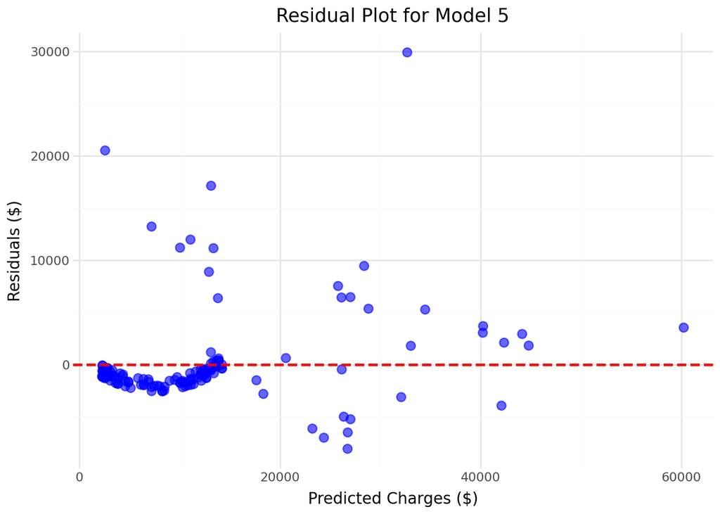

```python
best_model_idx = models_summary['MSE'].idxmin()

# determine which model is best and get its predictions
if best_model_idx == 0:
    best_predictions = y_pred_1
    best_model_name = "Model 1"
elif best_model_idx == 1:
    best_predictions = y_pred_2
    best_model_name = "Model 2"
elif best_model_idx == 2:
    best_predictions = y_pred_3
    best_model_name = "Model 3"
elif best_model_idx == 3:
    best_predictions = y_pred_4
    best_model_name = "Model 4"
else:
    best_predictions = y_pred_5
    best_model_name = "Model 5"

residuals = y_test - best_predictions

# create residual plot dataframe
residual_df = pd.DataFrame({
    'predicted': best_predictions,
    'residuals': residuals
})

# create residual plot
residual_plot = (
    ggplot(residual_df, aes(x='predicted', y='residuals')) +
    geom_point(alpha=0.6, color='blue', size=3) +
    geom_hline(yintercept=0, linetype='dashed', color='red', size=1) +
    labs(
        title=f'Residual Plot for {best_model_name}',
        x='Predicted Charges ($)',
        y='Residuals ($)'
    ) +
    theme_minimal()
)

residual_plot
```

# Part Five: Full Exploration: Find the model that best predicts on the new data after being fit on the original data

## Data Prep

```python
# list to store all model results
results = []
```

## Model 1: Baseline - age, bmi, smoker with interactions

```python
df['age_smoker'] = df['age'] * df['smoker_yes']
df['bmi_smoker'] = df['bmi'] * df['smoker_yes']
df_new['age_smoker'] = df_new['age'] * df_new['smoker_yes']
df_new['bmi_smoker'] = df_new['bmi'] * df_new['smoker_yes']

X_train = df[['age', 'bmi', 'smoker_yes', 'age_smoker', 'bmi_smoker']]
y_train = df['charges']
X_test = df_new[['age', 'bmi', 'smoker_yes', 'age_smoker', 'bmi_smoker']]
y_test = df_new['charges']

model = LinearRegression()
model.fit(X_train, y_train)
y_pred = model.predict(X_test)
mse = mean_squared_error(y_test, y_pred)
results.append({'Model': 'Baseline: age, bmi, smoker + interactions', 'MSE': mse})
print(f"Model 1 MSE: {mse:,.2f}")
```

```
Model 1 MSE: 21,786,256.87
```

## Model 2: Add sex

```python
X_train = df[['age', 'bmi', 'smoker_yes', 'sex_male', 'age_smoker', 'bmi_smoker']]
X_test = df_new[['age', 'bmi', 'smoker_yes', 'sex_male', 'age_smoker', 'bmi_smoker']]

model = LinearRegression()
model.fit(X_train, y_train)
y_pred = model.predict(X_test)
mse = mean_squared_error(y_test, y_pred)
results.append({'Model': 'Add sex', 'MSE': mse})
print(f"Model 2 MSE: {mse:,.2f}")
```

```
Model 2 MSE: 21,985,171.22
```

## Model 3: Add region

```python
region_cols = [col for col in df.columns if col.startswith('region_')]
X_train = df[['age', 'bmi', 'smoker_yes', 'sex_male', 'age_smoker', 'bmi_smoker'] + region_cols]
X_test = df_new[['age', 'bmi', 'smoker_yes', 'sex_male', 'age_smoker', 'bmi_smoker'] + region_cols]

model = LinearRegression()
model.fit(X_train, y_train)
y_pred = model.predict(X_test)
mse = mean_squared_error(y_test, y_pred)
results.append({'Model': 'Add region', 'MSE': mse})
print(f"Model 3 MSE: {mse:,.2f}")
```

```
Model 3 MSE: 22,478,707.56
```

## Model 4: Add polynomial terms for age (degree 2)

```python
df['age_squared'] = df['age'] ** 2
df_new['age_squared'] = df_new['age'] ** 2

X_train = df[['age', 'age_squared', 'bmi', 'smoker_yes', 'sex_male', 'age_smoker', 'bmi_smoker'] + region_cols]
X_test = df_new[['age', 'age_squared', 'bmi', 'smoker_yes', 'sex_male', 'age_smoker', 'bmi_smoker'] + region_cols]

model = LinearRegression()
model.fit(X_train, y_train)
y_pred = model.predict(X_test)
mse = mean_squared_error(y_test, y_pred)
results.append({'Model': 'Add age^2', 'MSE': mse})
print(f"Model 4 MSE: {mse:,.2f}")
```

```
Model 4 MSE: 22,390,305.93
```

## Model 5: Add polynomial terms for bmi (degree 2)

```python
df['bmi_squared'] = df['bmi'] ** 2
df_new['bmi_squared'] = df_new['bmi'] ** 2

X_train = df[['age', 'age_squared', 'bmi', 'bmi_squared', 'smoker_yes', 'sex_male',
              'age_smoker', 'bmi_smoker'] + region_cols]
X_test = df_new[['age', 'age_squared', 'bmi', 'bmi_squared', 'smoker_yes', 'sex_male',
                 'age_smoker', 'bmi_smoker'] + region_cols]

model = LinearRegression()
model.fit(X_train, y_train)
y_pred = model.predict(X_test)
mse = mean_squared_error(y_test, y_pred)
results.append({'Model': 'Add bmi^2', 'MSE': mse})
print(f"Model 5 MSE: {mse:,.2f}")
```

```
Model 5 MSE: 22,213,251.10
```

## Model 6: Add sex interactions with age and bmi

```python
df['age_sex'] = df['age'] * df['sex_male']
df['bmi_sex'] = df['bmi'] * df['sex_male']
df_new['age_sex'] = df_new['age'] * df_new['sex_male']
df_new['bmi_sex'] = df_new['bmi'] * df_new['sex_male']

X_train = df[['age', 'age_squared', 'bmi', 'bmi_squared', 'smoker_yes', 'sex_male',
              'age_smoker', 'bmi_smoker', 'age_sex', 'bmi_sex'] + region_cols]
X_test = df_new[['age', 'age_squared', 'bmi', 'bmi_squared', 'smoker_yes', 'sex_male',
                 'age_smoker', 'bmi_smoker', 'age_sex', 'bmi_sex'] + region_cols]

model = LinearRegression()
model.fit(X_train, y_train)
y_pred = model.predict(X_test)
mse = mean_squared_error(y_test, y_pred)
results.append({'Model': 'Add sex interactions', 'MSE': mse})
print(f"Model 6 MSE: {mse:,.2f}")
```

```
Model 6 MSE: 22,109,013.99
```

## Model 7: Add higher order polynomials (age^3, bmi^3)

```python
df['age_cubed'] = df['age'] ** 3
df['bmi_cubed'] = df['bmi'] ** 3
df_new['age_cubed'] = df_new['age'] ** 3
df_new['bmi_cubed'] = df_new['bmi'] ** 3

X_train = df[['age', 'age_squared', 'age_cubed', 'bmi', 'bmi_squared', 'bmi_cubed',
              'smoker_yes', 'sex_male', 'age_smoker', 'bmi_smoker', 'age_sex', 'bmi_sex'] + region_cols]
X_test = df_new[['age', 'age_squared', 'age_cubed', 'bmi', 'bmi_squared', 'bmi_cubed',
                 'smoker_yes', 'sex_male', 'age_smoker', 'bmi_smoker', 'age_sex', 'bmi_sex'] + region_cols]

model = LinearRegression()
model.fit(X_train, y_train)
y_pred = model.predict(X_test)
mse = mean_squared_error(y_test, y_pred)
results.append({'Model': 'Add age^3, bmi^3', 'MSE': mse})
print(f"Model 7 MSE: {mse:,.2f}")
```

```
Model 7 MSE: 23,257,083.38
```

## Model 8: Add age*bmi interaction

```python
df['age_bmi'] = df['age'] * df['bmi']
df_new['age_bmi'] = df_new['age'] * df_new['bmi']

X_train = df[['age', 'age_squared', 'age_cubed', 'bmi', 'bmi_squared', 'bmi_cubed',
              'smoker_yes', 'sex_male', 'age_smoker', 'bmi_smoker', 'age_sex', 'bmi_sex',
              'age_bmi'] + region_cols]
X_test = df_new[['age', 'age_squared', 'age_cubed', 'bmi', 'bmi_squared', 'bmi_cubed',
                 'smoker_yes', 'sex_male', 'age_smoker', 'bmi_smoker', 'age_sex', 'bmi_sex',
                 'age_bmi'] + region_cols]

model = LinearRegression()
model.fit(X_train, y_train)
y_pred = model.predict(X_test)
mse = mean_squared_error(y_test, y_pred)
results.append({'Model': 'Add age*bmi interaction', 'MSE': mse})
print(f"Model 8 MSE: {mse:,.2f}")
```

```
Model 8 MSE: 23,353,245.28
```

## Model 9: Add smoker interaction with age^2 and bmi^2

```python
df['age_squared_smoker'] = df['age_squared'] * df['smoker_yes']
df['bmi_squared_smoker'] = df['bmi_squared'] * df['smoker_yes']
df_new['age_squared_smoker'] = df_new['age_squared'] * df_new['smoker_yes']
df_new['bmi_squared_smoker'] = df_new['bmi_squared'] * df_new['smoker_yes']

X_train = df[['age', 'age_squared', 'age_cubed', 'bmi', 'bmi_squared', 'bmi_cubed',
              'smoker_yes', 'sex_male', 'age_smoker', 'bmi_smoker', 'age_sex', 'bmi_sex',
              'age_bmi', 'age_squared_smoker', 'bmi_squared_smoker'] + region_cols]
X_test = df_new[['age', 'age_squared', 'age_cubed', 'bmi', 'bmi_squared', 'bmi_cubed',
                 'smoker_yes', 'sex_male', 'age_smoker', 'bmi_smoker', 'age_sex', 'bmi_sex',
                 'age_bmi', 'age_squared_smoker', 'bmi_squared_smoker'] + region_cols]

model = LinearRegression()
model.fit(X_train, y_train)
y_pred = model.predict(X_test)
mse = mean_squared_error(y_test, y_pred)
results.append({'Model': 'Add polynomial smoker interactions', 'MSE': mse})
print(f"Model 9 MSE: {mse:,.2f}")
```

```
Model 9 MSE: 23,108,258.94
```

## Model 10: Simplified - remove cubic terms, keep important interactions

```python
X_train = df[['age', 'age_squared', 'bmi', 'bmi_squared',
              'smoker_yes', 'sex_male', 'age_smoker', 'bmi_smoker',
              'age_bmi', 'age_squared_smoker', 'bmi_squared_smoker'] + region_cols]
X_test = df_new[['age', 'age_squared', 'bmi', 'bmi_squared',
                 'smoker_yes', 'sex_male', 'age_smoker', 'bmi_smoker',
                 'age_bmi', 'age_squared_smoker', 'bmi_squared_smoker'] + region_cols]

model = LinearRegression()
model.fit(X_train, y_train)
y_pred = model.predict(X_test)
mse = mean_squared_error(y_test, y_pred)
results.append({'Model': 'Simplified (no cubic)', 'MSE': mse})
print(f"Model 10 MSE: {mse:,.2f}")
```

```
Model 10 MSE: 22,527,109.96
```

## Summary and Best Model Selection

```
ALL MODELS SUMMARY
                                    Model          MSE
Baseline: age, bmi, smoker + interactions 2.178626e+07
                                  Add sex 2.198517e+07
                     Add sex interactions 2.210901e+07
                                Add bmi^2 2.221325e+07
                                Add age^2 2.239031e+07
                               Add region 2.247871e+07
                    Simplified (no cubic) 2.252711e+07
       Add polynomial smoker interactions 2.310826e+07
                         Add age^3, bmi^3 2.325708e+07
                  Add age*bmi interaction 2.335325e+07


BEST MODEL: Baseline: age, bmi, smoker + interactions
MSE: 21,786,256.87
```

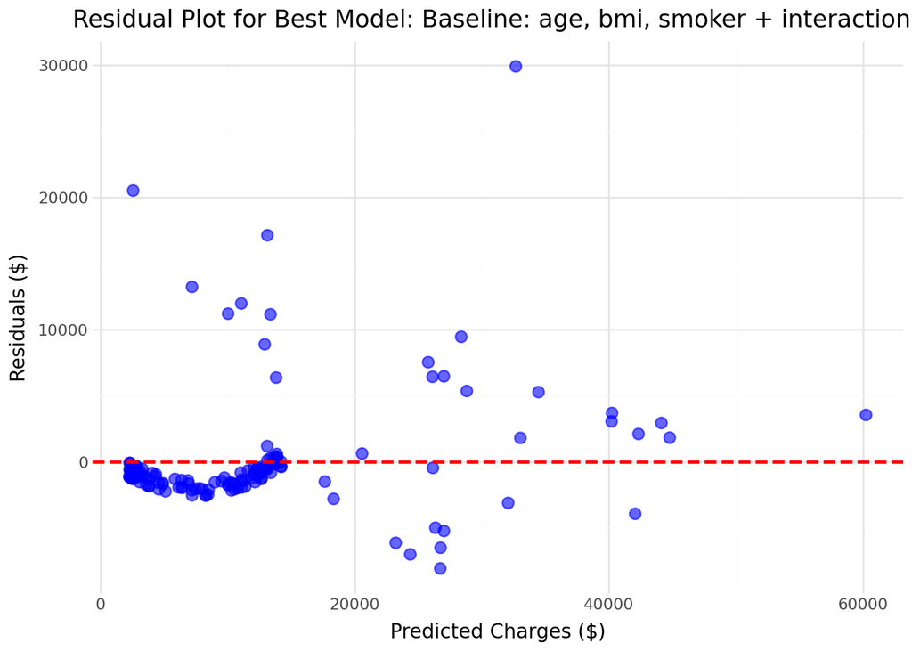

```python
print("ALL MODELS SUMMARY")

results_df = pd.DataFrame(results)
results_df = results_df.sort_values('MSE')
print(results_df.to_string(index=False))

best_model_name = results_df.iloc[0]['Model']
best_mse = results_df.iloc[0]['MSE']



print("\n")
print(f"BEST MODEL: {best_model_name}")
print(f"MSE: {best_mse:,.2f}")

# refit the best model and create residual plot
# x_train, y_train from best model
X_train = df[['age', 'bmi', 'smoker_yes', 'age_smoker', 'bmi_smoker']]
y_train = df['charges']

X_test = df_new[['age', 'bmi', 'smoker_yes', 'age_smoker', 'bmi_smoker']]
y_test = df_new['charges']

best_model = LinearRegression()
best_model.fit(X_train, y_train)
best_predictions = best_model.predict(X_test)

residuals = y_test - best_predictions

# create residual plot dataframe
residual_df = pd.DataFrame({
    'predicted': best_predictions,
    'residuals': residuals
})

# create residual plot
residual_plot = (
    ggplot(residual_df, aes(x='predicted', y='residuals')) +
    geom_point(alpha=0.6, color='blue', size=3) +
    geom_hline(yintercept=0, linetype='dashed', color='red', size=1) +
    labs(
        title=f'Residual Plot for Best Model: {best_model_name}',
        x='Predicted Charges ($)',
        y='Residuals ($)'
    ) +
    theme_minimal()
)

residual_plot
```

The model that best fits the data is the model that uses age, bmi, and smokeras predictors, with both quantitative variables having an interaction term with the smoker variable. The MSE is 2.178626e+07 which is lower than the rest, meaning that its predictions are closer to the actual insurance charges compared to the other models.

# Additional Diagnostics

```python
# additional diagnostics
print("MODEL DIAGNOSTICS")
print(f"Mean Residual: ${residuals.mean():,.2f}")
print(f"Std Dev of Residuals: ${residuals.std():,.2f}")
print(f"Max Positive Residual: ${residuals.max():,.2f}")
print(f"Max Negative Residual: ${residuals.min():,.2f}")
print(f"RMSE: ${np.sqrt(best_mse):,.2f}")
```

```
MODEL DIAGNOSTICS
Mean Residual: $142.01
Std Dev of Residuals: $4,681.81
Max Positive Residual: $29,922.61
Max Negative Residual: $-8,073.72
RMSE: $4,667.58
```